# R Project

Tools For Data Science

Author

Tristan Cameron

## **Instructions**

In this project you will be working with R base and Tidyverse.

1. *Render* the empty file to make sure everything is working
2. Consistently *Render* the file each time you answer a question

⚠️ Students enrolled in CAP4755 should only solve: **1, 2, 3, 4, 6, 7, 8, and 9.**

## R Base (40%)

1. Compute the difference between the current year and the year you started coding divide this by the difference between the current year and the year you were born. Multiply this with 100 to get the percentage of your life you have been programming.

```r
#Code here
x = (2025-2022) / (2025 - 2000) * 100
x
```

```
[1] 12
```

2. Compute the mean of the square root of a vector of 100 random numbers.

```r
#Code here
# generate 100 random numbers
random = c(abs(rnorm(100)))
random
```

```
  [1] 0.1121752154 1.3956203452 0.5730842333 1.1044361793 1.2826177025
  [6] 1.3209005601 0.6940155634 0.1337596161 0.1237390999 0.4574345317
 [11] 0.8663348676 0.4961978270 1.9779750957 1.6911837392 0.2295322082
 [16] 0.4335086645 0.2742350910 0.2783517630 0.3269608234 0.2681785097
 [21] 1.5375952231 1.4794366851 0.5422026617 0.9348965264 1.3716881618
 [26] 1.0687566694 0.4490779649 0.3690225746 0.9612231526 1.1342121855
 [31] 0.4629607880 0.9607916089 0.4029979691 1.0874839797 0.8078706023
 [36] 1.5647540166 2.0787435629 0.2420115287 0.1326216849 0.8691049348
 [41] 0.7271301038 1.0630466906 0.0349744494 0.2906791204 0.8451716207
 [46] 0.1648274135 0.5298261583 0.7689915931 1.3609459923 0.8238666471
 [51] 0.9568498420 1.5727985825 0.3952447192 2.0248293754 2.9299250105
 [56] 2.1362056130 0.5582080971 1.1313084860 0.4766155653 1.1456413986
 [61] 1.1603667206 0.8066292890 2.0188655462 0.9315648145 0.4819788237
 [66] 0.0635083548 0.2666974104 1.5151798486 0.0474815688 1.1761780875
 [71] 0.6792066783 1.6076801366 0.5230024649 1.3500377828 0.2946511246
 [76] 1.7044975917 0.1746948768 0.5037355048 1.9293608825 0.7902182891
 [81] 0.3687904269 2.0700426769 0.1986338834 0.0006508289 1.0910270628
 [86] 0.6455635408 0.0408548813 0.0871654772 0.7122950275 0.6604654531
 [91] 1.2176524079 1.1313824230 1.1288991287 1.7064408135 0.8117744183
 [96] 0.1379699703 0.7285615572 0.0319718382 0.1300552751 1.6416770397
```

```r
# find the sqrt
root = sqrt(random)
root
```

```
  [1] 0.33492569 1.18136376 0.75702327 1.05092159 1.13252713 1.14930438
  [7] 0.83307596 0.36573162 0.35176569 0.67633907 0.93077111 0.70441311
 [13] 1.40640503 1.30045520 0.47909520 0.65841375 0.52367460 0.52759053
 [19] 0.57180488 0.51785955 1.23999807 1.21632096 0.73634412 0.96690047
 [25] 1.17119092 1.03380688 0.67013280 0.60747228 0.98041989 1.06499398
 [31] 0.68041222 0.98019978 0.63482121 1.04282500 0.89881622 1.25090128
 [37] 1.44178485 0.49194667 0.36417260 0.93225798 0.85271924 1.03104156
 [43] 0.18701457 0.53914666 0.91933216 0.40598943 0.72789158 0.87692166
 [49] 1.16659590 0.90767100 0.97818702 1.25411267 0.62868491 1.42296499
 [55] 1.71170237 1.46157641 0.74713325 1.06362986 0.69037350 1.07034639
 [61] 1.07720319 0.89812543 1.42086788 0.96517605 0.69424695 0.25200864
 [67] 0.51642755 1.23092642 0.21790266 1.08451744 0.82413996 1.26794327
 [73] 0.72318909 1.16191126 0.54281776 1.30556409 0.41796516 0.70974327
 [79] 1.38901436 0.88894223 0.60728118 1.43876429 0.44568361 0.02551135
 [85] 1.04452241 0.80346969 0.20212590 0.29523800 0.84397573 0.81269026
 [91] 1.10347288 1.06366462 1.06249665 1.30630809 0.90098525 0.37144309
 [97] 0.85355817 0.17880671 0.36063177 1.28127945
```

```r
# find the mean
mean(root)
```

```
[1] 0.8509276
```

3. Make a vector from 1 to 100. Make a `for-loop` which runs through the whole vector. Multiply the elements which are smaller than 20 or larger than 80 by 10 and the other elements by 0.1.

```r
#Code here
vector = seq(1:100)
i = numeric()
for (i in 1:100) {
  if (vector[i] < 20 || vector[i] > 80) {
    vector[i] = vector[i] * 10
  } else {
    vector[i] = vector[i] * .1
  }
}
vector
```

```
  [1]   10.0   20.0   30.0   40.0   50.0   60.0   70.0   80.0   90.0  100.0
 [11]  110.0  120.0  130.0  140.0  150.0  160.0  170.0  180.0  190.0    2.0
 [21]    2.1    2.2    2.3    2.4    2.5    2.6    2.7    2.8    2.9    3.0
 [31]    3.1    3.2    3.3    3.4    3.5    3.6    3.7    3.8    3.9    4.0
 [41]    4.1    4.2    4.3    4.4    4.5    4.6    4.7    4.8    4.9    5.0
 [51]    5.1    5.2    5.3    5.4    5.5    5.6    5.7    5.8    5.9    6.0
 [61]    6.1    6.2    6.3    6.4    6.5    6.6    6.7    6.8    6.9    7.0
 [71]    7.1    7.2    7.3    7.4    7.5    7.6    7.7    7.8    7.9    8.0
 [81]  810.0  820.0  830.0  840.0  850.0  860.0  870.0  880.0  890.0  900.0
 [91]  910.0  920.0  930.0  940.0  950.0  960.0  970.0  980.0  990.0 1000.0
```

4. Write a *`function`* to combine questions 2 and 3, so that you can feed it an integer `n` you like (as argument). The function 1) generates `n` random number, 2) multiplies the elements which are smaller than 20 or larger than 80 by 10 and the other elements by 0.1, then 3) returns the mean of the square root of the vector.

```r
#Code here
thisFunction = function(n) {
  random = c(abs(rnorm(n)))
  root = sqrt(random)
  root_mean = mean(root)
  vector = seq(1:n)
  i = numeric()
  for (i in 1:n) {
    if (vector[i] < 20 || vector[i] > 80) {
      vector[i] = vector[i] * 10
    } else {
      vector[i] = vector[i] * .1
    }
  }
  return (data.frame("Random vector" = random, "Square root" = root, "Mean" = root_mean, "Adjusted vector" = vector))
}
thisFunction(84)
```

```
   Random.vector Square.root      Mean Adjusted.vector
1     0.48660490   0.6975707 0.8428042            10.0
2     0.78508410   0.8860497 0.8428042            20.0
3     0.30643487   0.5535656 0.8428042            30.0
4     0.48242076   0.6945652 0.8428042            40.0
5     0.78216477   0.8844008 0.8428042            50.0
6     2.17107160   1.4734557 0.8428042            60.0
7     1.48162618   1.2172207 0.8428042            70.0
8     0.85509297   0.9247124 0.8428042            80.0
9     0.84331786   0.9183234 0.8428042            90.0
10    0.76346613   0.8737655 0.8428042           100.0
11    0.13334659   0.3651665 0.8428042           110.0
12    0.87134703   0.9334597 0.8428042           120.0
13    1.17527671   1.0841018 0.8428042           130.0
14    0.50301665   0.7092367 0.8428042           140.0
```

[output cut: 70 more lines]

## R Tidyverse (60%)

### Baby names distribution data

We will look into the distribution of baby names. Use Tidyverse to answer the questions. This data set has over 2 millions rows from 1880 to 2022 It was provided by the Social Security Administration. It has the following variables:

- year: birth year
- sex: Female or Male
- name: baby name
- counts: number of babies named “name” in that year with that sex

#### Data Wrangling

Read the data in R and called it **`bbnames`**:

```r
# load packages
library(data.table)
library(tidyverse)
library(dplyr)

# Load the data - take a minute to load :)
bbnames = fread("https://pages.uwf.edu/acohen/teaching/datasets/babynames.csv", drop = "V1")
bbnames
```

```
              name    sex counts  year
            <char> <char>  <int> <int>
      1:      Mary      F   7065  1880
      2:      Anna      F   2604  1880
      3:      Emma      F   2003  1880
      4: Elizabeth      F   1939  1880
      5:    Minnie      F   1746  1880
     ---
2085154:    Zuberi      M      5  2022
2085155:      Zydn      M      5  2022
2085156:     Zylon      M      5  2022
2085157:    Zymeer      M      5  2022
2085158:   Zymeire      M      5  2022
```

```r
# Code here
```

5. Find the number of babies (names) born in the same year. (hints: use `group_by` and `summarise`). Then, find which year had the highest number of babies:

```r
#Code here
#Group by year and count number of babies
yearly_counts <- bbnames %>% group_by(year) %>% summarise(baby_count = n())

#Find year with most babies
most_babies <- yearly_counts %>% arrange(desc(baby_count)) %>% slice(1)
print(yearly_counts)
```

```
# A tibble: 143 × 2
    year baby_count
   <int>      <int>
 1  1880       2000
 2  1881       1934
 3  1882       2127
 4  1883       2084
 5  1884       2297
 6  1885       2294
 7  1886       2392
 8  1887       2373
 9  1888       2651
10  1889       2590
# ℹ 133 more rows
```

```r
print(most_babies)
```

```
# A tibble: 1 × 2
   year baby_count
  <int>      <int>
1  2008      35094
```

6. Find the most popular, all time, name for each sex (hints: answer for females starts with **M** and males with **J**):

```r
#Code here
#summarise counts by name and gender
total_counts <- bbnames %>% group_by(sex, name) %>% summarise(total_count = sum(counts), groups = 'drop')

#find most popular name for each gender
most_popular_names <- total_counts %>% group_by(sex) %>% slice_max(total_count, n = 1, with_ties = F) %>% ungroup()

print(most_popular_names)
```

```
# A tibble: 2 × 4
  sex   name  total_count groups
  <chr> <chr>       <int> <chr>
1 F     Mary      4134713 drop
2 M     James     5214844 drop
```

7. Create a new data frame while creating a new variable `age` and filter by `age` - Pick a threshold that would keep only people who may still alive (you may use the age expectancy):

```r
#Code here
#Create new variable and calculate age
new_data <- bbnames %>% mutate(age = 2025 - year) %>% filter(age <= 80)

print(new_data)
```

```
             name    sex counts  year   age
           <char> <char>  <int> <int> <num>
      1:     Mary      F  59280  1945    80
      2:    Linda      F  41462  1945    80
      3:  Barbara      F  38274  1945    80
      4: Patricia      F  35841  1945    80
      5:    Carol      F  30387  1945    80
     ---
1672820:   Zuberi      M      5  2022     3
1672821:     Zydn      M      5  2022     3
1672822:    Zylon      M      5  2022     3
1672823:   Zymeer      M      5  2022     3
1672824:  Zymeire      M      5  2022     3
```

#### Visualization

8. Use ggplot to plot the distribution of the name *John, x-axis is `year`* and y-axis is `counts`. Use `geom_bar()`, `geom_line()`, and `facet_wrap()` to separate females and males (use `scale="free"` to free the scales) .

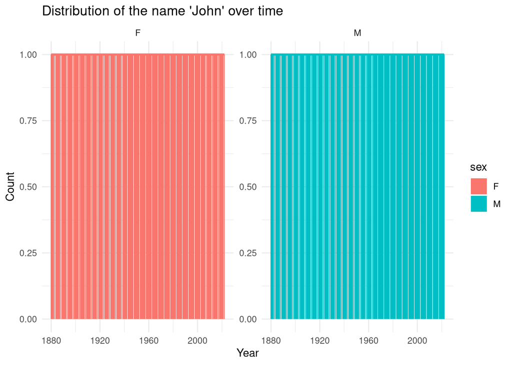

```r
#Code here
library(ggplot2)
john_data <- subset(bbnames, name == "John")

ggplot(john_data, aes(x = year)) +
  geom_bar(aes(fill = sex), position = "dodge") +
  geom_line(stat = "count", aes(group = sex, color = sex), size = 1) +
  facet_wrap(~ sex, scales = "free") +
  labs(title = "Distribution of the name 'John' over time",
       x = "Year",
       y = "Count") +
  theme_minimal()
```

9. Use ggplot to plot the distribution of the name of your choice, *x-axis is `year`* and y-axis is `counts`. Use `geom_bar()`, `geom_line()`, and `facet_wrap()` to separate females and males (use `scale="free"` to free the scales) .

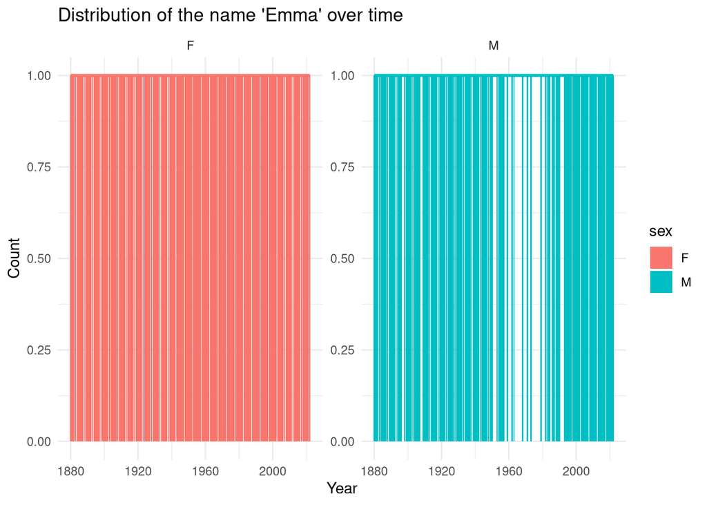

```r
#Code here
emma_data <- subset(bbnames, name == "Emma")

ggplot(emma_data, aes(x = year)) +
  geom_bar(aes(fill = sex), position = "dodge") +
  geom_line(stat = "count", aes(group = sex, color = sex), size = 1) +
  facet_wrap(~ sex, scales = "free") +
  labs(title = "Distribution of the name 'Emma' over time",
       x = "Year",
       y = "Count") +
  theme_minimal()
```

### Pilots certification data

Data was obtained from the Federation Aviation Administration (FAA) in June 2023 on pilot certification. The data has over 450000 pilots records and contained the following:

- ID: pilot ID
- STATE: US state where the pilot lives
- CertLevel: the certification level (Airline, Commercial, Student, Sport, Private, and Recreational),
- MedClass: the medical class,
- MedExpMonth: the medical expire month, and
- MedExpYear: the medical expire year.

Read the data in R and called it **`pilots`**:

```r
# Code here

# load packages
library(data.table)
library(tidyverse)

# Load the data
pilots = fread("https://pages.uwf.edu/acohen/teaching/datasets/pilotscertification.csv")
pilots
```

```
              ID  STATE MedClass MedExpMonth MedExpYear CertLevel
          <char> <char>    <int>       <int>      <int>    <char>
     1: A0000014     FL        3          10       2023   Airline
     2: A0000030     GA        3           8       2019   Private
     3: A0000087     NH       NA          NA         NA   Airline
     4: A0000113     CA        1          11       2023   Airline
     5: A0000221     AZ        1           8       2023   Airline
    ---
450693: C1819748     FL       NA          NA         NA   Student
450694: C1819777     IN       NA          NA         NA   Student
450695: C1819942     FL       NA          NA         NA   Student
450696: C1820011     OH        3           5       2025   Student
450697: C1820025     GA       NA          NA         NA   Student
```

10. Find how many pilots per certification level will have their medical certification expires the current year and month

```r
# Code here
# Get current year and month
current_year <- year(Sys.Date())
current_month <- month(Sys.Date())

# Filter for pilots whose medical certification expires this year and month
pilots_expiring <- pilots %>%
  filter(MedExpYear == current_year, MedExpMonth == current_month)

# Group by certification level and count the number of pilots per certification level
pilots_count <- pilots_expiring %>%
  group_by(CertLevel) %>%
  summarise(Count = n())

print(pilots_count)
```

```
# A tibble: 6 × 2
  CertLevel    Count
  <chr>        <int>
1 Airline         84
2 Commercial     316
3 Private       1692
4 Recreational     2
5 Sport            3
6 Student        290
```